# Best Reproducable Map competition at GISRUK2019

Hyesop Shin  
2019-04-25

Just before the GISRUK2019 conference, a mapping competition was announced by Robin Lovelace who was one of the instructors in the Spatial data in R workshop. I was keen on participating this competition because I use `R` and `GIS` for my PhD project, and there were some outcomes that I could use for the challenge. However, my confidence slowly diminished after I spotted the title **Reproducable** after the *Best*. What does this mean? For me it meant transparent first, and good-looking next.

And…guess what? I won the competition! Yey!  
Take a look at my Kriging map of NO2 interpolation.

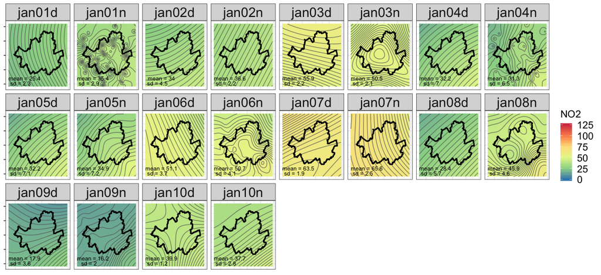

If you are interested in how I made this journey, you can follow my narratives below.  
If you want to want to know more about spatial interpolation and pollution, leave me a tweet `@hyesop`.

## Tidy data

First and foremost, my initial job was to clean my untidied chunks of codes. That is, to separate paragrahs and put approrpiate indentation (`ctrl + I` / `cmd + I`) for each code chunk. I also added some annotation to give some help.

## Where to find data and results?

[Visit: Hyesop Shin’:’s Best reproducible map competition for GISRUK 2019](https://github.com/Robinlovelace/geocompr/issues/376#issuecomment-486105726) [Visit: Hyesop’s Repo](https://github.com/mrsensible/GISRUK2019)

[Visit: Others Best reproducible map competition for GISRUK 2019](https://github.com/Robinlovelace/geocompr/issues/376)

## Some tweets

Tweet 1

> I am happy (and boasting a bit) to be a winner of the Best Reproducable Map competition at [#gisruk2019](https://twitter.com/hashtag/gisruk2019?src=hash&ref_src=twsrc%5Etfw). Many thanks to [@robinlovelace](https://twitter.com/robinlovelace?ref_src=twsrc%5Etfw) for his inspiration in [#rstats](https://twitter.com/hashtag/rstats?src=hash&ref_src=twsrc%5Etfw) and [#giscience](https://twitter.com/hashtag/giscience?src=hash&ref_src=twsrc%5Etfw)! [pic.twitter.com/Bi7fMCLwWG](https://t.co/Bi7fMCLwWG)

> — Hyesop Shin (@hyesop) [April 24, 2019](https://twitter.com/hyesop/status/1121095129685688321?ref_src=twsrc%5Etfw)

Tweet 2

> Congratulations Hyesop🎉 Winning (and definitely [#reproducible](https://twitter.com/hashtag/reproducible?src=hash&ref_src=twsrc%5Etfw), eventually ; ) map can be found here: https://t.co/h8tAXiY1wV. Challenge to anyone making 🗺️s at [#GISRUK2019](https://twitter.com/hashtag/GISRUK2019?src=hash&ref_src=twsrc%5Etfw) and beyond: make them reproducible too! https://t.co/lmW1Gzib1A

> — Robin Lovelace (@robinlovelace) [April 24, 2019](https://twitter.com/robinlovelace/status/1121114601414901764?ref_src=twsrc%5Etfw)

Tweet 3

> [pic.twitter.com/uIpwH3Hc3H](https://t.co/uIpwH3Hc3H)

> — GISRUK conference 2019 (@GISRUK) [April 24, 2019](https://twitter.com/GISRUK/status/1121069825361620993?ref_src=twsrc%5Etfw)